# Part II - Determinants of Loan Outcome Status in Prosper P2P Loan Data¶

## by Cvetana Decheva

## Investigation Overview

This presentation summarises our findings on the subject of factors related to P2P loan default/charge-off rate. All data stem from a data set provided by Prosper Marketplace, Inc., which is a San Francisco, California-based P2P lending company. The last record in the original data frame was made on 03.11.2014.

## Dataset Overview

The data set used in this report contains 113,937 loans with 81 variables on each loan. The last update was made on 03.11.2014

[Data Source](https://s3.amazonaws.com/udacity-hosted-downloads/ud651/prosperLoanData.csv)

[Variable Dictionary](https://docs.google.com/spreadsheets/d/1gDyi_L4UvIrLTEC6Wri5nbaMmkGmLQBk-Yx3z0XDEtI/edit#gid=0)

The outcome variable that we are seeking to predict/explain is loan outcome status.

Out of the multitude of variables that could be considered predictors of loan outcome, we selected variables that are described in a paper by [Serrano-Cinca, Gutierrez-Nieto & Lopez-Palacios (2015)](https://www.researchgate.net/publication/282426542_Determinants_of_Default_in_P2P_Lending). They grouped predictor variables together in the following manner:

### 1) Borrower Assessment.

This category consists of customer credit rating and loan interest rate. Prosper uses two different customer scoring systems (one consisting of 7 grades and another consisting of 10 grades) and, additionally, a customer credit score range provided by a consumer credit rating agency.

### 2) Loan Characteristics.

The characteristics of a loan are its purpose and amount. There is a fairly clear hypothesis related to the relationship between loan purpose and the probability of default, i.e., consumer loans (e.g., a wedding loan) are generally less risky than a loan for a small business. The relationship between the loan amount and the probability of default is less clear (some studies show a positive correlation, while others show a negative correlation).

### 3) Borrower Characteristics.

The borrower characteristics are income, housing and employment.

### 4) Borrower Credit History.

Borrower credit history is characterized by:

4.1) Time since first loan (i.e., credit history lenght) and number of total and open loans;

4.2) Number of open revolving accounts and the monthly payment on those;

4.3) "Revolving Utilization": "Revolving line utilization rate, or the amount of credit the borrower is using relative to all available revolving credit";

4.4) Current delinquencies, number of past delinquencies and amount of delinquencies on loans;

4.5) Number of inquiries by creditors (totally and for a current period);

4.6) Derogatory public records (Prosper saves data for the last 12 months and for the last 10 years).

The Prosper data set does not contain a "revolving utilization" variable. There is a variable 'BankcardUtilization' ("the percentage of available revolving credit that is utilized at the time the credit profile was pulled.") which could be construed as revolving utilization rate.

The rest of the credit history variables are represented in the Prosper data set.

### 5) Borrower Indebtedness.

Borrower Indebtedness variables are the following: loan amount to annual income, annual payment to annual income and debt to income ratio. The Prosper data set only contains one of these three variables: 'DebtToIncomeRatio'.

Additionally, the **loan term** could be one of the factors determining default rate.

## Key Findings

The following classification into 'weak' and 'strong' predictors is based only on inspection of plots (presented here).

#### Strong predictors:

- interest rate (quadratic, with a peak at approximately 30-32%)
- 7-level rating or 'Prosper Rating' (linear)
- 10-level rating or 'Prosper Score' (could be interpreted as linear, quadratic or cubic)
- customer credit rating by a professional credit rating agency (linear)
- loan term (with three categories, 12, 36, and 60 months, trend linear or exponential)
- income range (linear)
- sum of derogatory public records for the last 10 years (linear)
- sum of derogatory public records for the last 12 months (there is a difference between the two categories)
- debt-to-income ratio (could be interpreted as linear or cubic)

#### Weak predictors:

- loan amount (could be interpreted as quadratic, probably moderated by other variables such as purpose, income and debt-to-income ratio)
- employment status duration (default rate seems to grow with this variable, however the trend is not clear)
- homeownership (very small difference in default rate between the categories, possibly moderated by other variables)
- borrower credit history (default rate seems to grow from a certain value of this variable onward)
- number of current credit lines (one value is associated with a much higher default rate than the rest: zero)
- number of open credit lines (the same as current credit lines)
- sum of loans for the last 7 years (seemingly linear, but very weak)
- number of open revolving accounts (one value is associated with a much higher default rate than the rest: zero)
- open revolving monthly payment (same as open revolving accounts)
- revolving utilization or 'Bankcard Utilization' (two values are associated with a much higher default rate than the rest: 0% and 100% or higher)
- number of current delinquencies on loans (possibly quadratic with peak at 3-5 delinquencies)
- amount delinquent of loans (possibly quadratic with a peak in the category \$352-3,040)
- sum of delinquencies for the last 7 years (no obvious trend)
- sum of inquiries by creditors for the last 6 months (one value is associated with a much higher default rate than the rest: 7 or more inquiries)
- total sum of inquiries by creditors (one value is associated with a much higher default rate than the rest: 20 or more inquiries)

#### Unordered categorical variables:

- loan purpose (some categories have very low default rates, while others have much higher ones, which is why we also investigated the combination between loan purpose and other predictors)

**Strong predictors** of default would be redundant in a prediction model, especially the different credit rating variables (all of which are strongly correlated to the interest rate, as theoretical models propose). Deciding which of them to include into a model would go beyond the score of this discussion. The 'weak' predictors, on the other hand, could have important influence as part of a regression model. A necessary preparatory step of such a model would be to decide on a suitable transformation method.

**Unordered categorical variables**, as, for instance, the loan purpose should also be included in a prediction model. Plotting the combinations of loan purpose with other variables showed that certain categories of loan purpose are clearly distinct in terms of default rate, interest rate, loan size, income and so forth.

## Loan Outcome Status: 4 Categories

Between 13.07.2009 and 28.02.2014 there were 23,222 completed loans (with data on each of the variables of interest, cancelled loans excluded).

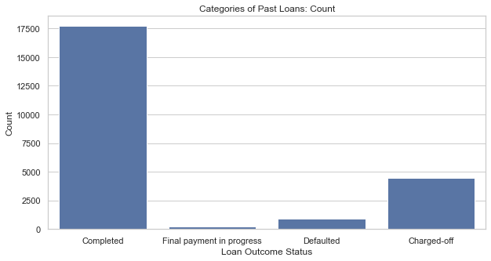

## Loan Outcome Status: 2 Categories

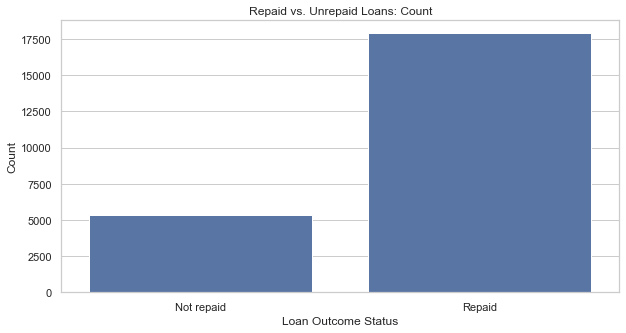

## Interest Rate

The minimum interest rate is 4% and the maximum is 36%. The (first) mode is 32%. The distribution is multimodal.

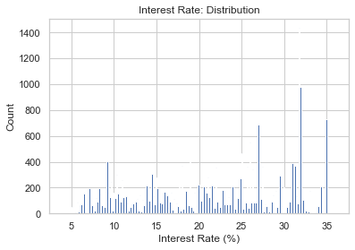

## Percentage Bar Plot of Loan Purpose

The most popular purpose category in completed loans by far is debt consolidation (n = 11,839), followed by the "umbrella" category "other" (n = 4,243) and home improvement (n = 2,433). Business loans are next with n = 1,606.

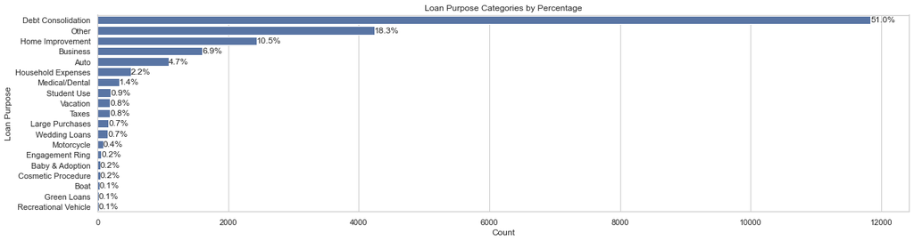

## Loan Amount

The size of completed loans is between \$1,000 and \\$35,000. The median value is \$5,000 and the mode is \\$4,000. The distribution is positively skewed and multimodal.

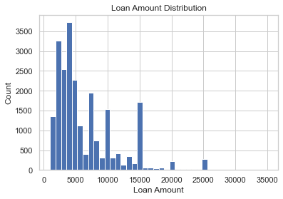

## Loan Purpose vs. Loan Amount

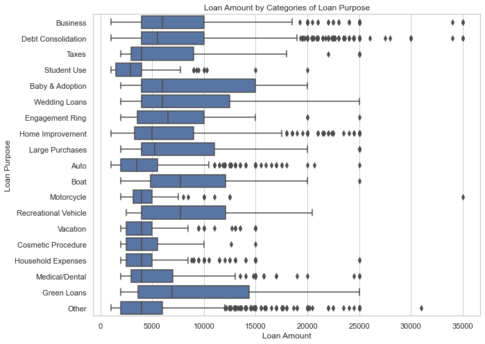

## Loan Term vs. Loan Amount

Prosper lends out in three possible loan terms: 12, 36, or 60 months. The terms are associated with a difference in loan amount as well as in interest rate. Here, we only display the relationship between loan term and loan size. The medians of loan amount of 12-month and 36-month term are approximately equal. The median amount of 60-month loans is higher. 36-month and 60-month loans contain higher outliers (> \$35,000) compared to 12-month loans (< \\$28,000).

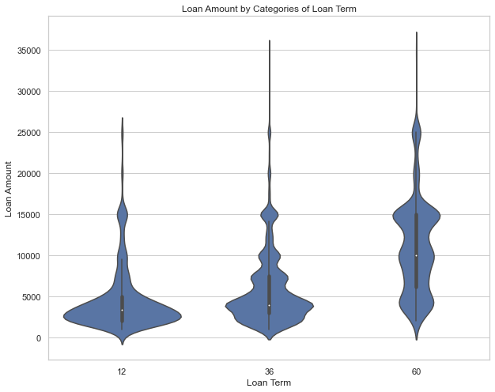

## Percentage of Unrepaid Loans by Categories of Ordinal and Categorical Variables

The following graphs display how each predictor variable (transformed to ordinal if necessary) is associated with the probability of default. The percentage of defaulted and charged-off loans for each category of the predictor is shown.

## Borrower Assessment Variables

The first group of predictors is 'Borrower Assessment Variables' which consists of interest rate and borrower credit rating variables.

## Percentage of Unrepaid Loans by Interest Rate Level

The interest rate was transformed into an ordinal variable of 16 levels (with 2%-increment). The relationship between interest rate and loan outcome status seems roughly quadratic. The peak is in the 30-31.9% group. The mode of the interest rate (32%) is located in the next bin: 32-33.9%.

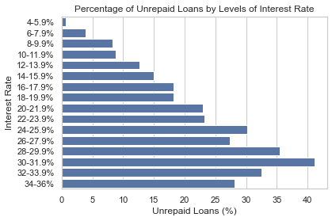

## Percentage of Unrepaid Loans by Levels of 'Prosper Rating'

'Prosper Rating (Alpha)' has seven levels, from 'HR' (worst) to 'AA' (best). The relationship between 7-level rating and loan outcome status seems almost ideally linear: the percentage of not replaid loans falls consistently from the lowest to the highest rating group.

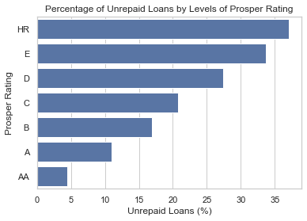

## Percentage of Unrepaid Loans by Levels of 'Prosper Score'

'Prosper Score' is another borrower credit rating variable. It has 10 levels: from 1 (worst) to 10 (best). The relationship between 'Prosper Score' and loan outcome status is roughly linear, although the trend seems less pronounced in the rating levels 2 (second to worst) to 5 (close to the middle of the scale). The levels from 5 to 10 (medium to best rating) seem to predict the loan outcome almost ideally. Furthermore, there is a pronounced difference between the worst score (1, with 44.32% unrepaid loans) and the second to worst score (2, with 32.41% of unrepaid loans).

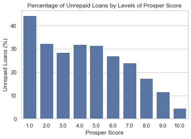

## Percentage of Unrepaid Loans by Levels of Professional Credit Rating

Prosper uses not only their own borrower credit ratings, but also a credit rating provided by a professional consumer credit rating agency. This variable is coded as two variables, signifying the upper and lower bound of an interval. Both are perfectly correlated, therefore we are using the upper bound variable.

The credit score intervals in question<sup>3</sup> are computed using a formula that considers factors such as payment history, overall debt levels, and the number of credit accounts the individual has open. A score between 740 and 850 suggests the individual has been consistently responsible, while scores between 700 to 750 are considered above average. Individuals with low credit scores, below 600, can take steps to improve them such as making payments on time, cutting down debt levels, and maintaining a zero balance on unused credit accounts.

The professional credit rating seems to predict loan outcome in an almost ideally linear manner. Borrowers with a rating of 889 or more had a zero default rate.

<sup>[3](#investopedia)</sup> [Credit Score Ranges: What Do They Mean?](https://www.investopedia.com/articles/personal-finance/081514/what-do-credit-score-ranges-mean.asp)

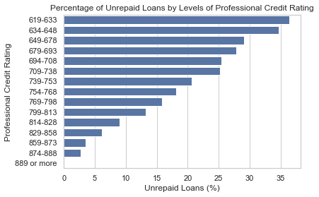

## Loan Characteristics¶

The second group of predictors is 'Loan Characteristics' which consists of loan purpose and loan amount. We can add the loan term to this group.

## Percentage of Unrepaid Loans by Loan Purpose

The highest percentage of unrepaid loans was in the categories 'Green Loans' (38.89%), 'Household Expenses' (34.98%), 'Medical/Dental' (33.64%), and 'Baby & Adoption' (32.43%). Business loans are located right after this group of high-risk loans (27.41% not repaid). The lowest-risk loan purposes are as follows: 'Motorcycle' (3.53% not repaid), 'Engagement Ring' (5.46%), 'Recreational Vehicle' (6.25%), and 'Boat' (10.71%).

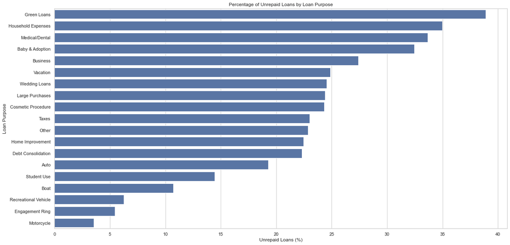

## Percentage of Unrepaid Loans by Loan Amount

The loan outcome status seems only loosely related to the loan size. The relationship is possibly quadratic (with a peak between \$4,000 and \\$5,000). A possible explanation would be that loan size interferes with other variables (loan purpose, interest rate, borrower rating, etc.) and the percentage of unrepaid loans per loan size is explained by those variables.

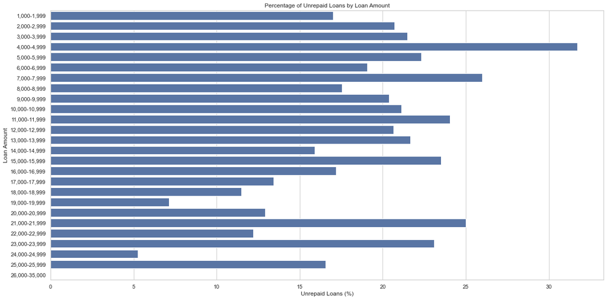

## Percentage of Unrepaid Loans by Loan Term

The percentage of defaults is the lowest for the shortest loan term (12 months): 4.28%. It rises to 22.58% for the loan term of 36 months and is even higher for the longest term (60 months): 32.46%.

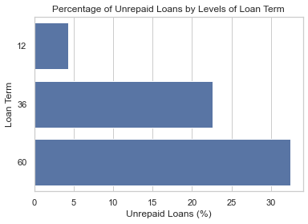

## Borrower Characteristics

The borrower characteristics are income, housing and employment.

The levels of employment status are not well defined ('Employed', 'Full-time' and 'Part-time', 'Other'); the categories 'Self-emplyed' and 'Not employed' have only 1 member each. Therefore, we are not including this variable in the presentation.

The variables included are: employment status duration (how many months has borrower spent in current employment situation), income range (incremented by \$25,000) and homeownership (yes or no).

## Percentage of Unrepaid Loans by Levels of Employment Status Duration

The ordinal variable Employment Status Duration increments by 24 months. It appears that duration of employment has no influence over loan outcome, although two of the highest categories (480-504 months and 528-755 months) had the highest rates of not repaid loans: 42.11%. A clear trend is not visible and the relationship between the two variables could be influenced by other variables.

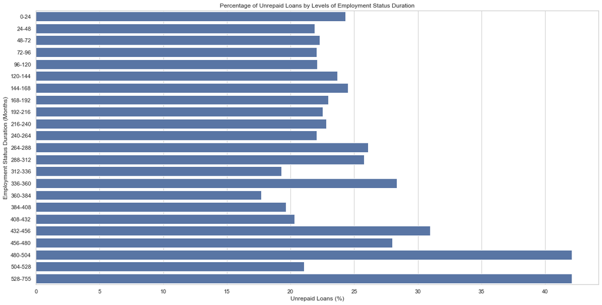

## Percentage of Unrepaid Loans by Levels of 'IncomeRange'

There appears to be a clear linear relationship between the borrower annual income and the loan outcome: borrowers with higher annual income are less likely to default.

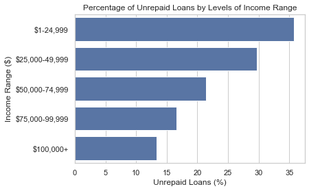

## Percentage of Unrepaid Loans by Categories of Homeownership

There is a slighly lower percentage of not repaid loans in the group of borrowers who were home owners. It should be noted however that borrowers with a mortgage are also classified as homeowners, as the variable dictionary states ("A Borrower will be classified as a homowner if they have a mortgage on their credit profile or provide documentation confirming they are a homeowner.").

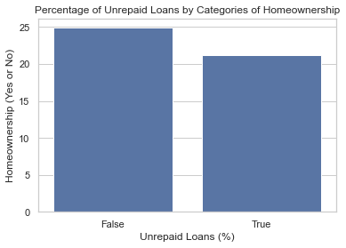

## Borrower Credit History Variables

Borrower credit history is characterized by credit history lenght, number of total and open loans, number of open revolving accounts and the monthly payment on those, revolving line utilization rate (i.e., percentage of available revolving credit that is utilized at the time the credit profile was pulled), current delinquencies, number of past delinquencies and amount of delinquencies on loans, inquiries by creditors (totally and for a current period), derogatory public records.

## Percentage of Unrepaid Loans by Credit History Lenght

The ordinal variable credit history lenght increments by 24 months. A longer credit history seems to predict a higher possibility of default. It could be that for borrowers with shorter credit history other variables play a more important role. Alternatively, the relationship could be explained by the fact that borrowers who defaulted early in their credit history were not lent anymore money.

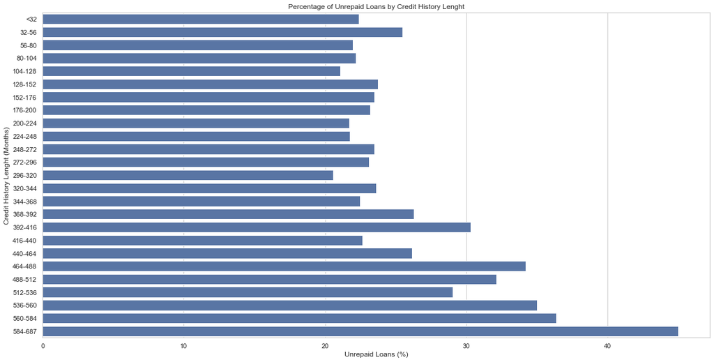

## Percentage of Unrepaid Loans by Number of Current Credit Lines

Borrowers with no current credit lines have a very high percentage of not repaid loans: 60%. This could mean that first-time borrowers are especially risky. For the rest of the categories of 'Current credit lines' no trend is visible.

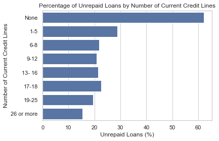

## Percentage of Unrepaid Loans by Number of Open Credit Lines

The trend here seems to repeat the previous variable, 'Current credit lines'.

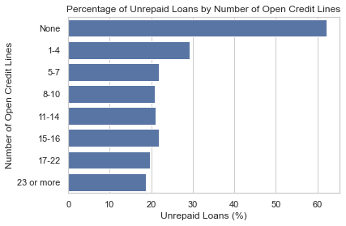

## Percentage of Unrepaid loans by Sum of Loans for the Last 7 Years

It seems that a higher number of loans a borrower has taken over the last 7 years could predict a lower possibility of default. This is probably due to the fact that borrowers who have not defaulted in the past are still lent money, while borrowers who defaulted, were subsequently rejected.

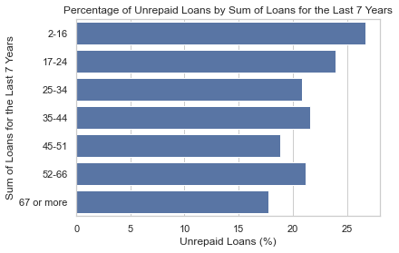

## Percentage of Unrepaid Loans by Number of Open Revolving Accounts

Customers with no open revolving accounts had the highest rate of unrepaid loans: 47.7%. For the rest of the categories, the trend is not clear.

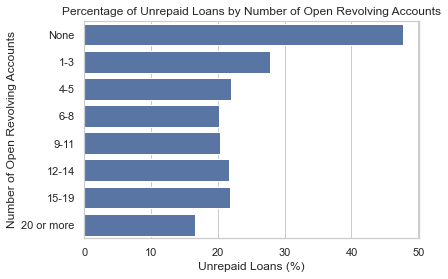

## Percentage of Unrepaid Loans by Percentage of Revolving Utilization ('Bankcard Utilization')

Borrowers who had either 0% or 100% or more utilization rate of their credit cards had a high percentage of nor repaid loans (33.1% and 34.18%). For the rest of the borrowers, the probability of default rose slightly from 0.1-25% to 75-100%.

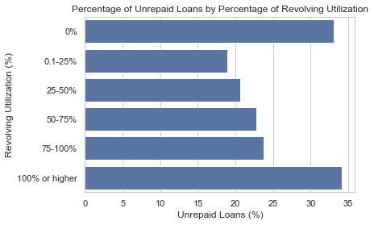

## Percentage of Unrepaid Loans by Number of Current Delinquencies

The relationship between percentage of unrepaid loans and number of current delinquencies appears to be quadratic with a peak at the group who had 3 to 5 delinquencies (39.73% not repaid). The percentage in the group with 6 or more delinquencies was lower (35.15%).

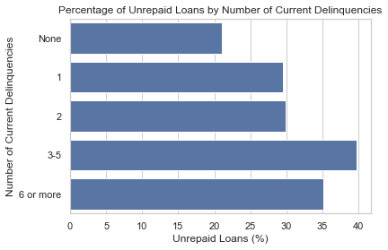

## Percentage of Unrepaid Loans by Number of Delinquencies on Loans for the Last 7 Years

The trend could be quadratic, although it is difficult to discern a peak. The relationship may be influenced by interfering variables.

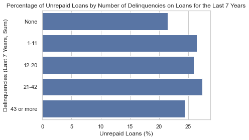

## Percentage of Unrepaid Loans by Amount Delinquent on Loans

The relationship between the amount of current delinquencies and the default rate appeared to be queadratic, with a peak in the group of \$352 to \\$3,040. However, the groups were formed not in equal intervals (due to skewness) and the real relationship may well be more complicated.

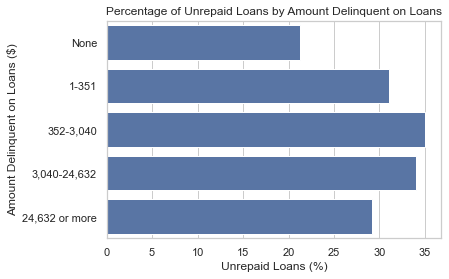

## Percentage of Unrepaid Loans by Number of Creditro Inquiries for the Last 6 Months

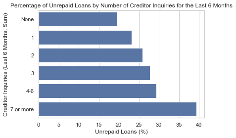

## Percentage of Unrepaid Loans by Sum of Creditor Inquiries

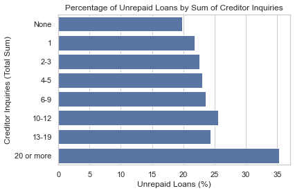

## Percentage of Unrepaid Loans by Sum of Derogatory Public Records for the Last 12 Months

Borrowers with 1 or more derogatory public records for the last 12 months had a substantially higher default rate than customers with no records: 36.8% vs. 22.81%.

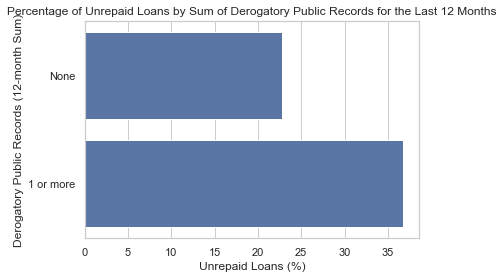

## Percentage of Unrepaid Loans by Sum of Derogatory Public Records for the Last 10 Years

There is a clear trend of increase in default rate from borrowers with no derogatory public records during the last 10 years to such with 2 or more (21.84% to 31.51%).

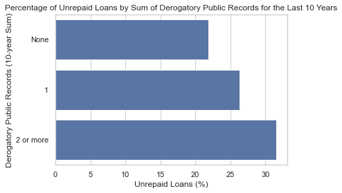

## Borrower Indebtedness

The Prosper data set contains only one variable of this category: debt-to-income ratio (DTI). The Prosper data dictionary states that 'This ['DebtToIncomeRatio'] value is Null if the debt to income ratio is not available.' Furthermore, all values larger than 1000% are entered as 1001% (i.e., this is an example of censored data).

## Percentage of Unrepaid Loans by Level of Debt-to-Income Ratio

The relationship between DTI an default rate could be construed as quadratic or approximately linear: the default rate grows from 0-10% towards 200% or more. The growth rate is not even, however, the intervals of DTI are also not even due to high skewness.

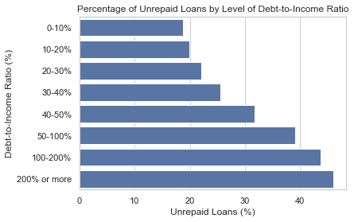